# MSc_CW2_13170192_D_Jaganjac

#1 Bayesian Networks and Naive Bayes Classifers

P(Buy Computer = Yes) = 14/30 = 0.47

P(Buy Computer = No) = 16/30 = 0.53

P( Credit Rating = Excellent | Income = High | Student = True | Buy Computer = Yes) = 1/2 = 0.5

P( Credit Rating = Fair | Income = High | Student = True | Buy Computer = Yes) = 1/2 = 0.5

P( Credit Rating = Excellent | Income = Low | Student = True | Buy Computer = Yes) = 2/5 = 0.4

P( Credit Rating = Fair | Income = Low | Student = True | Buy Computer = Yes) = 3/5 = 0.6

P( Credit Rating = Excellent | Income = High | Student = False | Buy Computer = Yes) = 2/3 = 0.67

P( Credit Rating = Fair | Income = High | Student = False | Buy Computer = Yes) = 1/3 = 0.33

P( Credit Rating = Excellent | Income = Low | Student = False | Buy Computer = Yes) = 2/4 = 0.5

P( Credit Rating = Fair | Income = Low | Student = False | Buy Computer = Yes) = 2/4 = 0.5

P( Credit Rating = Excellent | Income = High | Student = True | Buy Computer = No) = 2/4 = 0.5

P( Credit Rating = Fair | Income = High | Student = True | Buy Computer = No) = 2/4 = 0.5

P( Credit Rating = Excellent | Income = Low | Student = True | Buy Computer = No) = 2/7 = 0.29

P( Credit Rating = Fair | Income = Low | Student = True | Buy Computer = No) = 5/7 = 0.71

P( Credit Rating = Excellent | Income = High | Student = False | Buy Computer = No) = 2/3 = 0.67

P( Credit Rating = Fair | Income = High | Student = False | Buy Computer = No) = 1/3 = 0.33

P( Credit Rating = Excellent | Income = Low | Student = False | Buy Computer = No) = 1/2 = 0.5

P( Credit Rating = Fair | Income = Low | Student = False | Buy Computer = No) = 1/2 = 0.5

P(Student = True | Buy Computer = Yes) = 7/14 = 0.5

P(Student = False | Buy Computer = Yes) = 7/14 = 0.5

P(Student = True | Buy Computer = No) = 11/16 = 0.69

P(Student = False | Buy Computer = No) = 5/16 = 0.31

P(Income = High | Buy Computer = Yes) = 5/14 = 0.36

P(Income = Low | Buy Computer = Yes) = 9/14 = 0.64

P(Income = High | Buy Computer = No) = 7/16 = 0.44

P(Income = Low | Buy Computer = No) = 9/16 = 0.56

Instance.31

P(Buy Computer = Yes| Income = Low, Student = False, Credit Rating = Excellent) =

P(Credit Rating = Excellent| Income = Low, Student = False, Buy Computer = Yes) *

P(Income = Low | Buy Computer = Yes) *

P(Student = False | Buy Computer = Yes) *

P(Buy Computer = Yes)

= (0.5 * 0.64 * 0.5 * 0.47) = 0.075

P(Buy Computer = No| Income = Low, Student = False, Credit Rating = Excellent) =

P(Credit Rating = Excellent| Income = Low, Student = False, Buy Computer = No) *

P(Income = Low | Buy Computer = No) *

P(Student = False | Buy Computer = No) *

P(Buy Computer = No)

= (0.5 * 0.56 * 0.31 * 0.53) = 0.046

The predicted class label is “Yes” as P(Buy Computer = Yes| Income = Low, Student = False, Credit

Rating = Excellent) is greater than P(Buy Computer = No| Income = Low, Student = False, Credit

Rating = Excellent).

Instance.32

P(Buy Computer = Yes| Income = High, Student = False, Credit Rating = Fair) =

P(Credit Rating = Fair| Income = High, Student = False, Buy Computer = Yes) *

P(Income = High | Buy Computer = Yes) *

P(Student = False | Buy Computer = Yes) *

P(Buy Computer = Yes)

= (0.33 * 0.36 * 0.5 * 0.47) = 0.028

P(Buy Computer = No| Income = High, Student = False, Credit Rating = Fair) =

P(Credit Rating = Fair| Income = High, Student = False, Buy Computer = No) *

P(Income = High | Buy Computer = No) *

P(Student = False | Buy Computer = No) *

P(Buy Computer = No)

= (0.33 * 0.44 * 0.31 * 0.53) = 0.024

The predicted class label is “Yes” as P(Buy Computer = Yes| Income = High, Student = False, Credit

Rating = Fair) is greater than P(Buy Computer = No| Income = High, Student = False, Credit Rating = Fair).

P(Buy Computer = Yes) = 14/30 = 0.47

P(Buy Computer = No) = 16/30 = 0.53

P(Credit Rating = Excellent | Buy Computer = Yes) = 7/14 = 0.5

P(Credit Rating = Fair | Buy Computer = Yes) = 7/14 = 0.5

P(Credit Rating = Excellent | Buy Computer = No) = 7/16 = 0.44

P(Credit Rating = Fair | Buy Computer = No) = 9/16 = 0.56

P(Student = True | Buy Computer = Yes) = 7/14 = 0.5

P(Student = False | Buy Computer = Yes) = 7/14 = 0.5

P(Student = True | Buy Computer = No) = 11/16 = 0.7

P(Student = False | Buy Computer = No) = 5/16 = 0.3

P(Income = High | Buy Computer = Yes) = 5/14 = 0.4

P(Income = Low | Buy Computer = Yes) = 9/14 = 0.6

P(Income = High | Buy Computer = No) = 7/16 = 0.4

P(Income = Low | Buy Computer = No) = 9/16 = 0.6

Instance.31

P(Buy Computer = Yes | Income = Low, Student = False, Credit Rating = Excellent)=

P(Income = Low | Buy Computer = Yes)*

P(Student = False | Buy Computer = Yes)*

P(Credit Rating = Excellent | Buy Computer = Yes)*

P(Buy Computer = Yes)

= (0.6 * 0.5 * 0.5 * 0.47) = 0.07

P(Buy Computer = No | Income = Low, Student = False, Credit Rating = Excellent)=

P(Income = Low | Buy Computer = No)*

P(Student = False | Buy Computer = No)*

P(Credit Rating = Excellent | Buy Computer = No)*

P(Buy Computer = No)

= (0.6 * 0.3 * 0.44 * 0.53) = 0.042

The predicted class label is “Yes” as P(Buy Computer = Yes | Income = Low, Student = False, Credit Rating = Excellent) is

greater than P(Buy Computer = No | Income = Low, Student = False, Credit Rating = Excellent).

Instance.32

P(Buy Computer = Yes | Income = High, Student = False, Credit Rating = Fair)=

P(Income = High | Buy Computer = Yes)*

P(Student = False | Buy Computer = Yes)*

P(Credit Rating = Fair | Buy Computer = Yes)*

P(Buy Computer = Yes)

= (0.4 * 0.5 * 0.5 * 0.47) = 0.047

P(Buy Computer = No | Income = High, Student = False, Credit Rating = Fair)=

P(Income = High | Buy Computer = No)*

P(Student = False | Buy Computer = No)*

P(Credit Rating = Fair | Buy Computer = No)*

P(Buy Computer = No)

= (0.4 * 0.3 * 0.56 * 0.53) = 0.036

The predicted class label is “Yes” as P(Buy Computer = Yes | Income = High, Student = False, Credit Rating = Fair) is greater than P(Buy Computer = No | Income = High, Student = False, Credit Rating = Fair).

#2. Decision Trees and Random Forests

```r
Training_set = read.table("C:/Users/Diana Jaganjac/Documents/BDA_CW_2/RoomOccupancy_Training.txt",header=T, sep = ",")

Testing_set = read.table("C:/Users/Diana Jaganjac/Documents/BDA_CW_2/RoomOccupancy_Testing.txt",header=T, sep = ",")

room.occupancy <- tree(Occupancy ~., data = Training_set)

room.occupancy.rpart <- rpart(Occupancy ~., data = Training_set)

summary(room.occupancy)
```

```
##
## Classification tree:
## tree(formula = Occupancy ~ ., data = Training_set)
## Variables actually used in tree construction:
## [1] "Light"       "Temperature" "CO2"         "Humidity"
## Number of terminal nodes:  6
## Residual mean deviance:  0.07156 = 142.7 / 1994
## Misclassification error rate: 0.0125 = 25 / 2000
```

```r
occupancy.pred <-predict(room.occupancy, Testing_set, type = "class")

table(occupancy.pred, Testing_set$Occupancy)
```

```
##
## occupancy.pred  No Yes
##            No  195  16
##            Yes  45  44
```

```r
tab <- table(occupancy.pred, Testing_set$Occupancy)

sum(diag(tab))/sum(tab)
```

```
## [1] 0.7966667
```

```r
1-sum(diag(tab))/sum(tab)
```

```
## [1] 0.2033333
```

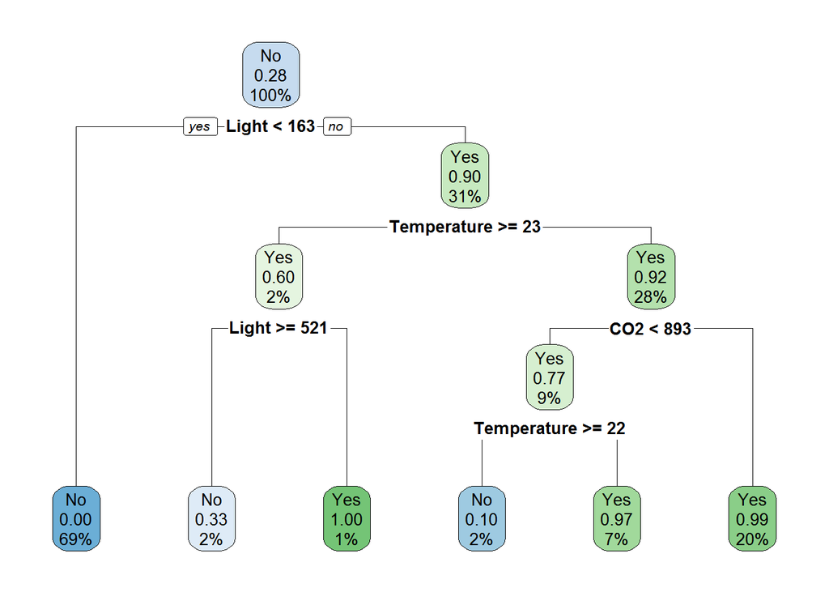

```r
rpart.plot(room.occupancy.rpart)
```

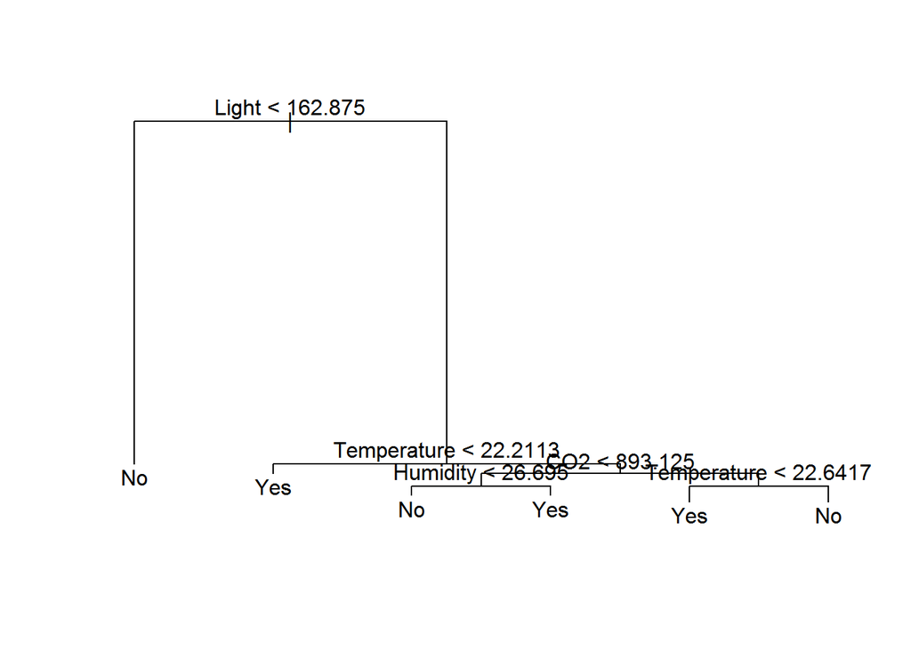

```r
plot(room.occupancy)
text(room.occupancy, pretty =0)
```

The predictive performance of the decision tree is approximatey 76% with a test error rate of 24% when mtry = 4 is used. Mtry = 4 is the best value to use for mtry as it produced the lowest test error rate, when compared to mtry = 1,2, 3 or 5.

```r
set.seed(15)

rf.occupancy <- randomForest(Occupancy ~., data = Training_set, mtry=4, importance = TRUE)

rf.pred <- predict(rf.occupancy, Testing_set, type = "class")

table(rf.pred, Testing_set$Occupancy)
```

```
##
## rf.pred  No Yes
##     No  180  13
##     Yes  60  47
```

```r
tab <- table(rf.pred, Testing_set$Occupancy)

sum(diag(tab))/sum(tab)
```

```
## [1] 0.7566667
```

```r
1-sum(diag(tab))/sum(tab)
```

```
## [1] 0.2433333
```

```r
importance(rf.occupancy)
```

```
##                     No       Yes MeanDecreaseAccuracy MeanDecreaseGini
## Temperature   41.94729  27.56141             36.36349         40.49819
## Humidity      15.10479  15.86846             19.24629         14.65208
## Light         54.44797 281.62742            123.97069        611.39758
## CO2           12.51760  29.80871             33.63144        122.50388
## HumidityRatio 13.74391  16.54046             19.04512         12.61202
```

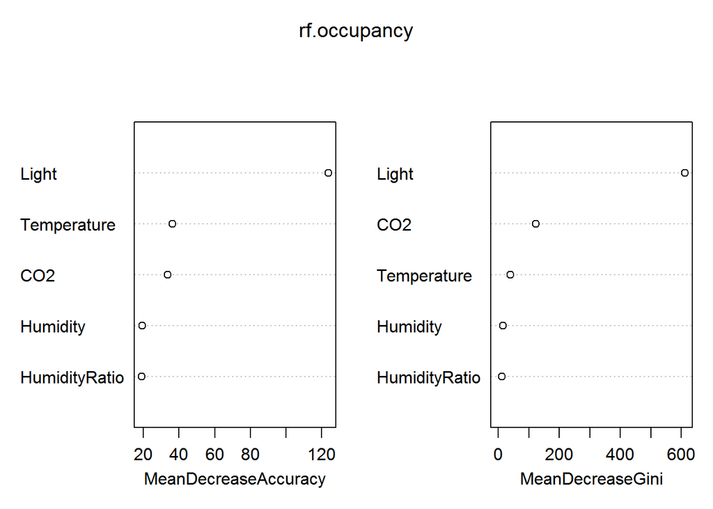

```r
varImpPlot(rf.occupancy)
```

#3. SVM

```r
Wine_Training = read.table("C:/Users/Diana Jaganjac/Documents/BDA_CW_2/WineQuality_training.txt",header=T, sep = ",")

Wine_Testing = read.table("C:/Users/Diana Jaganjac/Documents/BDA_CW_2/WineQuality_testing.txt",header=T, sep = ",")

tune.out <- tune(svm, quality~., data = Wine_Training, kernal = "linear", ranges = list(cost = c(0.01, 0.1, 1, 5, 10)))

summary(tune.out)
```

```
##
## Parameter tuning of 'svm':
##
## - sampling method: 10-fold cross validation
##
## - best parameters:
##  cost
##    10
##
## - best performance: 0.1766667
##
## - Detailed performance results:
##    cost     error dispersion
## 1  0.01 0.2646667 0.01708367
## 2  0.10 0.2116667 0.02872819
## 3  1.00 0.1946667 0.02978109
## 4  5.00 0.1813333 0.01995056
## 5 10.00 0.1766667 0.01981395
```

The predictive performance on the testing data-set of the linear svm classifier is 0.7125.

```r
svmfit.train <- svm(quality~., data = Wine_Training, kernal = "linear", cost =5)

quality.pred <- predict(svmfit.train, newdata = Wine_Testing, type = "response")

table(quality.pred, truth = Wine_Testing$quality)
```

```
##             truth
## quality.pred Bad Good
##         Bad  121   94
##         Good  21  164
```

```r
tab <- table(quality.pred, truth = Wine_Testing$quality)

sum(diag(tab))/sum(tab)
```

```
## [1] 0.7125
```

```r
1-sum(diag(tab))/sum(tab)
```

```
## [1] 0.2875
```

By performing a grid-search to find the optimal hyperparameters of svm by using the RBF kernal, the optimal cost is computed as cost = 5, and optimal gamma is computed as gamma = 0.5.

```r
tune.out.radial <- tune(svm, quality~., data = Wine_Training, kernal = "radial", ranges = list(cost = c(0.01, 0.1, 1, 5, 10), gamma = c(0.01, 0.03, 0.1, 0.5, 1)))

summary(tune.out.radial)
```

```
##
## Parameter tuning of 'svm':
##
## - sampling method: 10-fold cross validation
##
## - best parameters:
##  cost gamma
##     5   0.5
##
## - best performance: 0.159
##
## - Detailed performance results:
##     cost gamma     error dispersion
## 1   0.01  0.01 0.2890000 0.02846050
## 2   0.10  0.01 0.2526667 0.02729808
## 3   1.00  0.01 0.2350000 0.02267592
## 4   5.00  0.01 0.2090000 0.01515761
## 5  10.00  0.01 0.2036667 0.01418136
## 6   0.01  0.03 0.2653333 0.02767537
## 7   0.10  0.03 0.2423333 0.02514403
## 8   1.00  0.03 0.2103333 0.01605930
## 9   5.00  0.03 0.1970000 0.01855589
## 10 10.00  0.03 0.1973333 0.02181856
## 11  0.01  0.10 0.2680000 0.02409856
## 12  0.10  0.10 0.2163333 0.02268681
## 13  1.00  0.10 0.1943333 0.02222500
## 14  5.00  0.10 0.1830000 0.02268681
## 15 10.00  0.10 0.1793333 0.01851259
## 16  0.01  0.50 0.5053333 0.07498477
## 17  0.10  0.50 0.2306667 0.02153378
## 18  1.00  0.50 0.1636667 0.02687190
## 19  5.00  0.50 0.1590000 0.02205772
## 20 10.00  0.50 0.1636667 0.01801577
## 21  0.01  1.00 0.5116667 0.05666122
## 22  0.10  1.00 0.2470000 0.05886687
## 23  1.00  1.00 0.1606667 0.01844578
## 24  5.00  1.00 0.1613333 0.01925783
## 25 10.00  1.00 0.1623333 0.02078995
```

The predictive performance on the testing data-set of the RBF svm classifier is 0.6575.

```r
svmfit.radial <- svm(quality~., data = Wine_Training, kernal = "radial", cost =5, gamma = 0.5)

radial.pred <- predict(svmfit.radial, newdata = Wine_Testing)

table(radial.pred, truth = Wine_Testing$quality)
```

```
##            truth
## radial.pred Bad Good
##        Bad  113  108
##        Good  29  150
```

```r
tab <- table(radial.pred, truth = Wine_Testing$quality)

sum(diag(tab))/sum(tab)
```

```
## [1] 0.6575
```

```r
1-sum(diag(tab))/sum(tab)
```

```
## [1] 0.3425
```

By conducting ROC curve analysis we can see that the auroc value for the linear svm classifier is 0.7438858 and the auroc value for the RBF svm classifier is 0.688585. Therefore, the predictive performance of the linear svm classifier is higher compared to the RBF svm classifier.

```r
pred_linear <- prediction(as.numeric(quality.pred), as.numeric(Wine_Testing$quality))

perf_linear <- performance(pred_linear, measure = "tpr", x.measure = "fpr")

plot(perf_linear, col = "red", main = "Predictive Performance of Linear and RBF SVM Classifiers")

auroc <- performance(pred_linear, measure = "auc")
auroc_value <- auroc@y.values[[1]]

auroc_value
```

```
## [1] 0.7438858
```

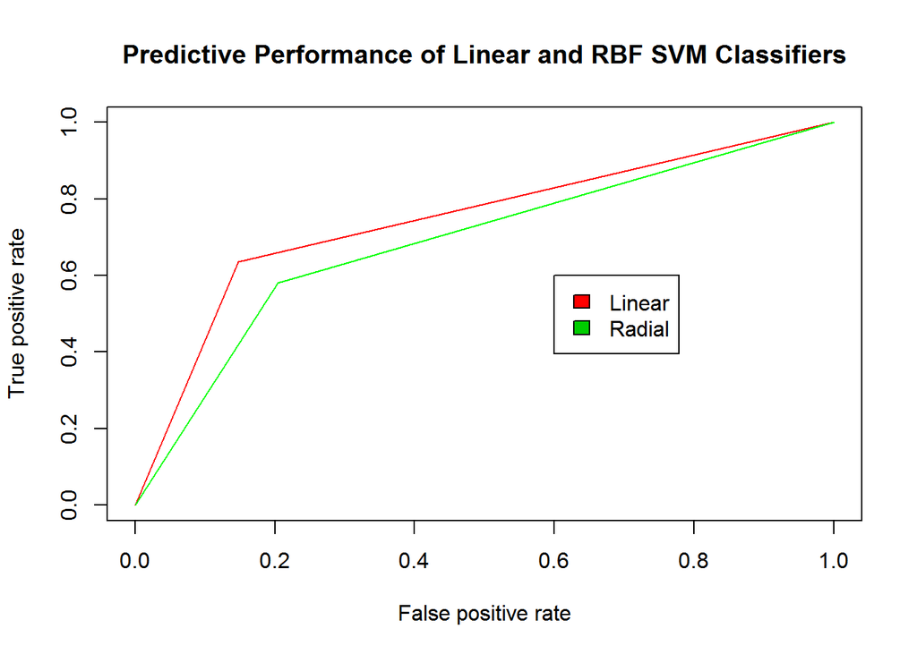

```r
pred_radial <- prediction(as.numeric(radial.pred), as.numeric(Wine_Testing$quality))

perf_radial <- performance(pred_radial, measure = "tpr", x.measure = "fpr")

plot(perf_radial, col = "green", add = TRUE)

legend(0.6, 0.6, c('Linear', 'Radial'), 2:4)
```

```r
auroc <- performance(pred_radial, measure = "auc")
auroc_value <- auroc@y.values[[1]]

auroc_value
```

```
## [1] 0.688585
```

#4. Hierarchical Clustering

```r
View(USArrests)
hc.complete <- hclust(dist(USArrests), method = "complete")
```

States belonging to cluster 1: Alabama, Alaska, Arizona, California, Delaware, Florida, Illinois, Louisiana, Maryland, Michigan, Mississippi, Nevada, New Mexico, New York, North Carolina, South Carolina.

States belonging to cluster 2: Arkansas, Colarado, Georgia, Massachusetts, Missouri, New Jersey, Oklahoma, Oregon, Rhode Island, Tennessee, Texas, Virginia, Wyoming, Washington.

States belonging to cluster 3: Connecticut, Hawaii, Idaho, Indiana, Iowa, Kansas, Kentucky, Maine, Minnesota, Montana, Nebraska, New Hampshire, North Dakota, Ohio, Pennsylvania, South Dakota, Utah, Vermont, West Virginia, Wisconsin.

```r
cutree(hc.complete, 3)
```

```
##        Alabama         Alaska        Arizona       Arkansas     California
##              1              1              1              2              1
##       Colorado    Connecticut       Delaware        Florida        Georgia
##              2              3              1              1              2
##         Hawaii          Idaho       Illinois        Indiana           Iowa
##              3              3              1              3              3
##         Kansas       Kentucky      Louisiana          Maine       Maryland
##              3              3              1              3              1
##  Massachusetts       Michigan      Minnesota    Mississippi       Missouri
##              2              1              3              1              2
##        Montana       Nebraska         Nevada  New Hampshire     New Jersey
##              3              3              1              3              2
##     New Mexico       New York North Carolina   North Dakota           Ohio
##              1              1              1              3              3
##       Oklahoma         Oregon   Pennsylvania   Rhode Island South Carolina
##              2              2              3              2              1
##   South Dakota      Tennessee          Texas           Utah        Vermont
##              3              2              2              3              3
##       Virginia     Washington  West Virginia      Wisconsin        Wyoming
##              2              2              3              3              2
```

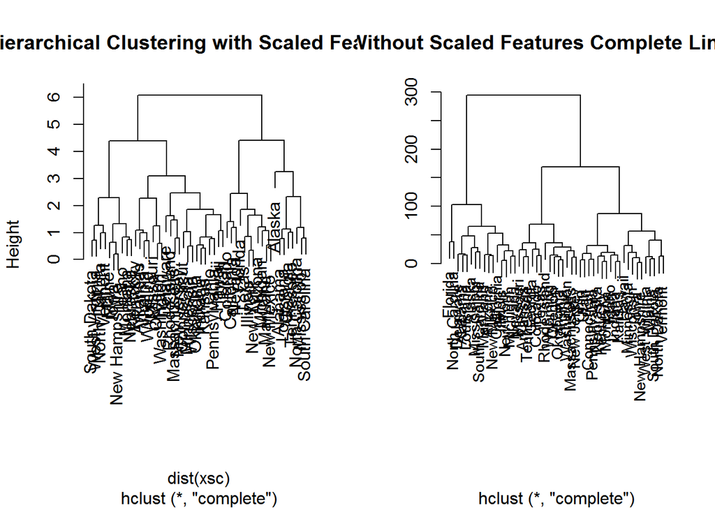

```r
xsc <- scale(USArrests)
par(mfrow = c(1,2))
plot(hclust(dist(xsc), method = "complete"), main = "Hierarchical Clustering with Scaled Features")
plot(hc.complete, xlab = "", ylab = "", cex = 0.9, main = "Without Scaled Features Complete Linkage")
```

Scaling the variables gives each variable equal importance in the hierarchical clustering performed. In my opinion, we should scale the variables before the inter-observation dissimilarities are computed. It is important to do this in order for each variable to be given equal weighting therefore giving a more accurate result. For example, for the USArrests dataset, many more assaults are committed than murders of rapes per 100,000 residents. Without scaling, more importance would then be given to assault than the other variables as assaults occur more often. By scaling, the variables are given equal importance and so murders and rapes are seen as equal to assault. This can be seen visually in part.c as the first dendrogram is more balanced compared to the second which is skewed to the left.

#5. PCA and K-Means Clustering

```r
set.seed(15)

y <- rep(c(1,2,3),20)
x <- matrix(rnorm(n = 3000, mean = 0, sd = 1), ncol = 50)

x[y==2,] = x[y==2,] - 0.7
x[y==3,] = x[y==3,] + 0.7

data <- cbind(y, x)

dim(data)
```

```
## [1] 60 51
```

```r
View(data)
```

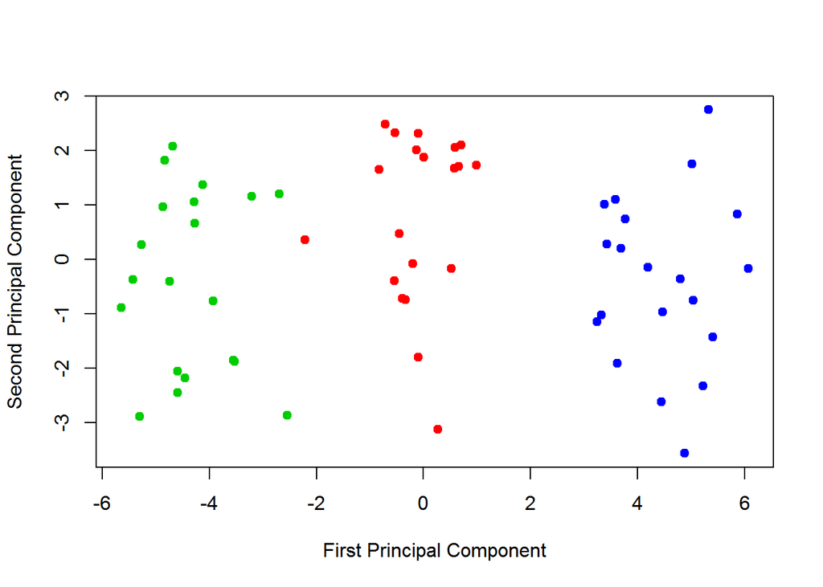

```r
pr.out <- prcomp(data, scale = TRUE)

plot(pr.out$x[,1:2], col= 2:4, pch =19, xlab ="First Principal Component", ylab="Second Principal Component")
```

The clusters are equally distributed amongst the class labels.

```r
km.out = kmeans(data, 3, nstart = 20)

table(km.out$cluster, y, dnn = c("Clusters", "Classes"))
```

```
##         Classes
## Clusters  1  2  3
##        1  0 20  0
##        2  0  0 20
##        3 20  0  0
```

```r
km.out$tot.withinss
```

```
## [1] 2886.003
```

Two of the clusters have now merged together to form a larger second cluster, whilst the smaller cluster contains 21 observations. The tot.withinss value is also greater than in (c) which indicates a greater total within-cluster sum of squares. This indicates a greater spread of the clusters compared to (c).

```r
km.out.2 = kmeans(data, 2, nstart = 20)

table(km.out.2$cluster, y, dnn = c("Clusters", "Classes"))
```

```
##         Classes
## Clusters  1  2  3
##        1  1 20  0
##        2 19  0 20
```

```r
km.out.2$tot.withinss
```

```
## [1] 3212.091
```

One of the previous clusters has now seperated to form two new clusters, which are both about half the size of the other two clusters. The tot.withinss value is lower than that of (c) which indicates a smaller spread of the clusters.

```r
km.out.4 = kmeans(data, 4, nstart = 20)

table(km.out.4$cluster, y, dnn = c("Clusters", "Classes"))
```

```
##         Classes
## Clusters  1  2  3
##        1 20  0  0
##        2  0  0 11
##        3  0  0  9
##        4  0 20  0
```

```r
km.out.4$tot.withinss
```

```
## [1] 2787.311
```

Performing K-means clustering with K = 3 on the first two principle components has resulted in a result which is similar to that in part (c). For example, the clusters are mostly equally seperated amongst the three classes. However, the tot.withinss value is much smaller than the same value for (c), and indicates a very small spread of the clusters, meaning the clusters are closer together than the clusters in (c).

```r
km.out.pca = kmeans(pr.out$x[,1:2], 3, nstart =20)

table(km.out.pca$cluster, y, dnn = c("Clusters", "Classes"))
```

```
##         Classes
## Clusters  1  2  3
##        1 19  0  0
##        2  1 20  0
##        3  0  0 20
```

```r
km.out.pca$tot.withinss
```

```
## [1] 184.3926
```

The results for (g) and for (b) are the same, as the clusters are equally distributed amongst the class labels. This is likely due to the mean-shift which was added which helped to seperate the data in to three distinct clusters. Nevertheless, by scaling the data the accuracy of the clustering algorithm is improved as all variables are given equal weighting/ importance. It is important to note that as the data is a simulated data-set, there are not a number of different scales (i.e. cm and kg) which need to be scaled, and as a mean-shift was performed, scaling is not so necessary for this data-set, as three distinct groups are already defined. Nevertheless, the tot.withinss value is smaller than the tot.withinns value in (c), indicating that it is worth scaling the variables as a pre-processing step before performing further analysis.

```r
km.out.scale = kmeans(scale(data), 3, nstart = 20)

table(km.out.scale$cluster, y, dnn = c("Clusters", "Classes"))
```

```
##         Classes
## Clusters  1  2  3
##        1  0  0 20
##        2 20  0  0
##        3  0 20  0
```

```r
km.out.scale$tot.withinss
```

```
## [1] 2143.623
```